# macodgent · 医学数据科学例行性分析工具箱（说明书）

版本 1.0.0 · 与示例教学数据集对齐

本说明书所有示例均基于示例教学数据集：**birthwt**（低出生体重研究，MASS）、**ovarian**（卵巢癌预后，survival）、**mtcars**、**infert**（配对病例对照）、**iris**，覆盖第 1–8 章的全部分析技术。

## 1. mc_gam

用途：拟合广义可加模型（GAM），在保持线性模型可解释性的同时，允许自变量以平滑（非线性）形式进入模型，自动捕捉曲线关系。 方法：基于 mgcv 包的 gam()，用样条（如 s(x)）表示平滑项，自动选择平滑自由度并给出显著性。 参数：data 为数据框；formula 形如 y ~ s(x1) + x2，其中 s() 包裹的项为平滑项，其余为线性项。 结果：返回列表，含 model（gam 对象，可用 plot() 看平滑曲线）、terms（各平滑项的自由度 edf、参考自由度、F 值与 p 值，用于判断该变量是否具非线性效应）。 注意：edf 接近 1 且 p 不显著，说明该变量近似线性、无需平滑；edf 很大可能过拟合。平滑项需要足够样本量才能稳定估计。依赖 mgcv（Suggests）。想看效应图用 plot(res$model, pages=1, shade=TRUE)。

**示例代码 / Example**

```
# 第 7 章：用 GAM 刻画孕期体重(lwt)对出生体重的非线性效应
birthwt &lt;- MASS::birthwt
res &lt;- mc_gam(birthwt, bwt ~ s(lwt) + smoke)
cat("平滑项表 / smooth terms:\n")
print(as.data.frame(res$terms), row.names = FALSE)
```

**运行结果 / Output**

平滑项表 / smooth terms: term edf ref.df statistic p.value s(lwt) 2.733537 3.425476 2.817939 0.03508487

## 2. mc_lasso

**示例代码 / Example**

```
# 第 7 章：用 Lasso 在 mtcars 的全部预测变量中做变量选择（mpg ~ .）
xvars &lt;- setdiff(names(mtcars), "mpg")
mc_lasso(mtcars, x = xvars, y = "mpg")$coefficients
```

**运行结果 / Output**

variable coefficient 1 cyl -0.89288058 2 disp 0.00000000 3 hp -0.01281976 4 drat 0.00000000 5 wt -2.78332595 6 qsec 0.00000000 7 vs 0.00000000 8 am 0.01347182 9 gear 0.00000000 10 carb 0.00000000

## 3. mc_ridge

用途：用岭回归（L2 正则化）处理多重共线性，稳定系数估计，适合「变量都重要但不想丢弃任何一个」的场景。 方法：基于 glmnet 包，alpha=0 即岭回归；对所有系数做等比例收缩（不置零），保留全部变量。 参数：data 为数据框；x 为自变量列名向量；y 为因变量列名；nfolds 为 CV 折数（默认 10）；family 默认 gaussian。 结果：返回含 coefficients（被收缩但均非零的系数表）的列表。 注意：与 Lasso 不同，岭回归的系数永远不会精确为 0，因此不做变量选择、只做系数收缩。它对共线性稳健（把方差分摊到相关变量上），但解释时变量仍全部保留。λ 越大收缩越强。依赖 glmnet（Suggests）。

**示例代码 / Example**

```
# 第 7 章：岭回归处理 mtcars 预测变量的多重共线性
xvars &lt;- setdiff(names(mtcars), "mpg")
mc_ridge(mtcars, x = xvars, y = "mpg")$coefficients
```

**运行结果 / Output**

variable coefficient 1 cyl -0.376364874 2 disp -0.005370836 3 hp -0.011393558 4 drat 1.055717325 5 wt -1.175325163 6 qsec 0.158738999 7 vs 0.801360486 8 am 1.558830973 9 gear 0.539424986 10 carb -0.521508008

## 4. mc_elastic_net

用途：用弹性网络（Elastic Net）兼顾 Lasso 的稀疏性与岭回归对共线性的稳健性，是二者之间的连续调节。 方法：基于 glmnet 包，alpha 在 0（纯岭）到 1（纯 Lasso）之间调节混合比例；alpha=0.5 是常用折中。 参数：data 为数据框；x 为自变量列名向量；y 为因变量列名；alpha 为混合参数（默认 0.5）；nfolds 为 CV 折数；family 默认 gaussian。 结果：返回含 coefficients（按所选 α 收缩后的系数表，部分可能为 0）的列表。 注意：当自变量成组高度相关时，弹性网络比 Lasso 更稳健——它会把整组相关变量一起保留或一起剔除，而非随机留一个。α 越接近 1 越偏向变量选择，越接近 0 越偏向系数收缩。依赖 glmnet（Suggests）。

**示例代码 / Example**

```
# 第 7 章：弹性网络（alpha = 0.5）兼顾变量选择与系数收缩
xvars &lt;- setdiff(names(mtcars), "mpg")
mc_elastic_net(mtcars, x = xvars, y = "mpg", alpha = 0.5)$coefficients
```

**运行结果 / Output**

variable coefficient 1 cyl -0.666000654 2 disp -0.002502274 3 hp -0.013392346 4 drat 0.513286598 5 wt -2.003746238 6 qsec 0.000000000 7 vs 0.141640125 8 am 0.887814191 9 gear 0.000000000 10 carb -0.251165982

## 5. mc_rcs

**示例代码 / Example**

[output not shown]

**运行结果 / Output**

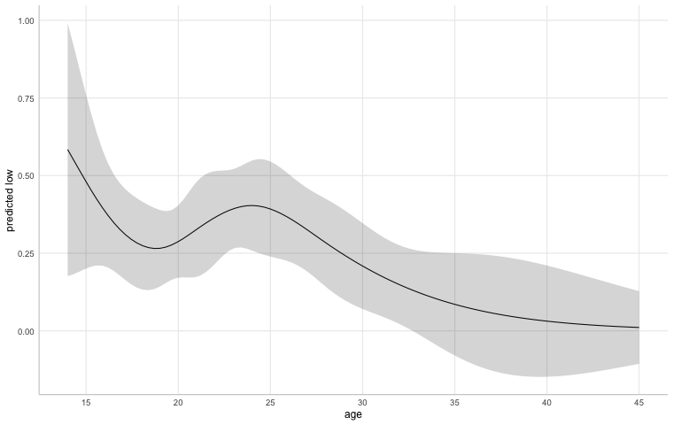

## 6. mc_quantile_reg

用途：用分位数回归刻画自变量对结局不同分位点（如中位数、上下四分位）的影响，特别适合存在异方差或关注极端分位（如低收入、高死亡风险）的场景。 方法：基于 quantreg 包的 rq()，最小化加权的绝对残差，可同时估计多个分位点的系数。 参数：data 为数据框；formula 形如 y ~ x；taus 为要估计的分位点向量，默认 c(0.25, 0.5, 0.75)。 结果：返回各分位点系数的数据框（含截距与自变量斜率），可比较不同分位下斜率的差异。 注意：若 taus 上不同分位的自变量斜率明显不同（如异方差时），说明条件分布形态随 x 变化——这是普通均值回归（OLS）看不到的信息。分位数回归对异常值稳健。依赖 quantreg（Suggests）。

**示例代码 / Example**

```
# 第 7 章：出生体重的条件分位数回归（不同分位下孕期体重 lwt 的斜率）
birthwt &lt;- MASS::birthwt
mc_quantile_reg(birthwt, bwt ~ lwt + age, taus = c(0.25, 0.5, 0.75))
```

**运行结果 / Output**

# A tibble: 9 × 5 term estimate conf.low conf.high tau &lt;chr&gt; &lt;dbl&gt; &lt;dbl&gt; &lt;dbl&gt; &lt;dbl&gt; 1 (Intercept) 1774. 1207. 2382. 0.25 2 lwt 4.71 -0.0497 9.00 0.25 3 age 3.09 -24.0 39.3 0.25 4 (Intercept) 2044. 1337. 2920. 0.5 5 lwt 6.33 2.33 9.15 0.5 6 age 5.08 -9.04 30.6 0.5 7 (Intercept) 2384. 1771. 3432. 0.75 8 lwt 5.82 -0.0568 11.4 0.75 9 age 12.8 -14.6 48.4 0.75

## 7. mc_pcr

用途：当预测变量高度相关（多重共线）时，用主成分回归稳定估计。 方法（自研）：① 对预测变量做标准化（中心化+缩放）；② PCA 得到互不相关的 主成分；③ 若未指定主成分数，用自研 k 折交叉验证按预测均方误差（MSE）选最优 个数；④ 以选出的主成分拟合线性回归；⑤ 将主成分系数反变换回原始变量尺度 （利用旋转矩阵与标准化参数）。 参数：\code{data} 为数据框；\code{formula} 形如 \code{y ~ x1 + x2 + ...}； \code{ncomp} 为主成分个数（NULL 时由 CV 自动选）；\code{k} 为交叉验证折数 （默认 5）；\code{seed} 为 CV 随机种子。 结果：返回列表——\code{best_ncomp}（选定主成分数）、\code{cv_table}（各候选 数的 CV-MSE）、\code{coef_original}（原始尺度系数+截距）、\code{performance} （R²/调整 R²/RMSE）、\code{plot}（CV-MSE 随主成分数变化图）、\code{fit} （最终 lm 对象）。 注意：PCR 对预测变量做了标准化，系数与标准化后的量纲相关；分类变量应先 哑变量化再纳入。本函数仅依赖基础 R，无需额外安装包。

**示例代码 / Example**

[output not shown]

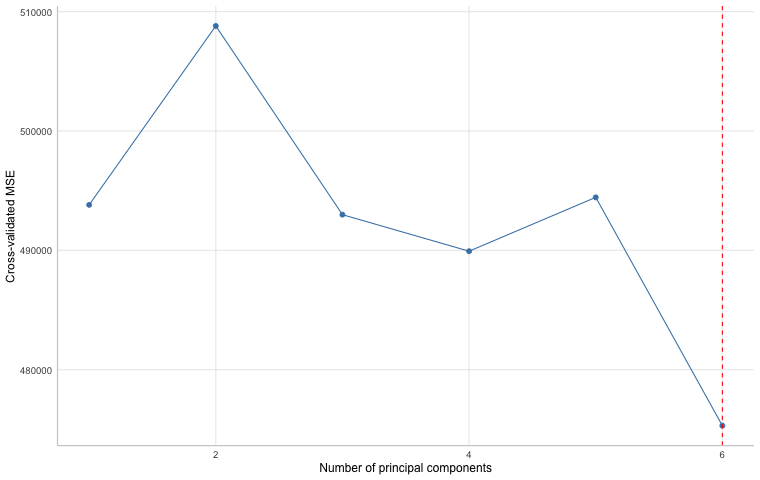

## 8. mc_nnet_reg

用途：用神经网络拟合预测变量与连续结局间的非线性关系。 依赖：需要 nnet 包（位于 Suggests）；未安装时给出明确提示。 方法：\code{nnet::nnet(y ~ ., linout = TRUE, size = hidden)}，隐藏层节点数由 \code{hidden} 控制；数据自动标准化以加快收敛。 参数：\code{data} 为数据框；\code{formula} 形如 \code{y ~ x1 + x2 + ...}； \code{hidden} 为隐藏层节点数（默认 5）；\code{maxit} 为最大迭代次数（默认 200）； \code{seed} 为随机种子。 结果：返回列表——\code{fit}（nnet 对象）、\code{predictions}（拟合值）、 \code{rmse}、\code{plot}（预测 vs 实测散点）。 注意：神经网络对尺度敏感，本函数内部对预测变量做了标准化；结果对随机初始化 敏感，建议设置 \code{seed} 以保证可复现。节点数过多易过拟合，可用 mc_model_compare() 或交叉验证比较不同结构。

**示例代码 / Example**

[output not shown]

[figure not shown]

## 9. mc_contingency

用途：构建分类变量的列联表并做独立性/关联检验，是分析分类变量关联的第一步，且覆盖 4.3 节要求的三种方法。 方法： \itemize{ \item \code{"chisq"}（默认）：对 2×2 及以上表做卡方独立性检验；\code{correct=TRUE} 时对 2×2 表加 Yates 连续性校正，防止小样本高估显著性。当表为 2×2 时，额外用 Fisher 精确法给出 OR 及其 95% CI。 \item \code{"fisher"}：对任意 r×c 表用 \code{stats::fisher.test} 做精确检验（适合小样本或期望频数过小的情形）。 \item \code{"cmh"}：需提供 \code{strata} 分层变量，构造三维列联表后用 \code{stats::mantelhaen.test} 做 Cochran-Mantel-Haenszel 检验，在控制分层因素后判断行-列关联是否仍然存在，并返回共同比值比（common OR）。 } 参数：.data 为数据框；row/col 为行、列变量名；correct 控制卡方连续性校正；method 选择检验类型；strata 为 CMH 所需的层变量名。 结果：返回列表，含 table（列联表，三维时分层展开）、test（检验数据框：test/statistic/df/p.value），并视方法附带 OR / commonOR。 注意：卡方检验要求期望频数不能过小（一般要求足够比例的格子期望 &gt;5），否则改用 \code{method="fisher"}。CMH 适用于存在混杂分层（如多中心研究）时估计「调整后的」关联。OR&gt;1 提示正关联；置信区间跨 1 表示关联不显著。

**示例代码 / Example**

```
# 第 4 章 4.3 节：以 birthwt 演示三种独立性检验
birthwt &lt;- MASS::birthwt

## ---- 卡方独立性检验（2x2 附 Fisher OR）----
res &lt;- mc_contingency(birthwt, row = "smoke", col = "low")
cat("---- 列联表 / table ----\n"); print(res$table)
cat("\n---- 卡方检验 / chi-square ----\n"); print(res$test, row.names = FALSE)
cat("\n---- 比值比 OR / odds ratio ----\n"); print(res$OR, row.names = FALSE)

## ---- Fisher 精确检验（小样本/期望频数过小时）----
res2 &lt;- mc_contingency(birthwt, row = "smoke", col = "low", method = "fisher")
print(res2$test, row.names = FALSE); print(res2$OR, row.names = FALSE)

## ---- CMH 分层检验：控制高血压(ht)后吸烟与低体重的共同 OR ----
res3 &lt;- mc_contingency(birthwt, row = "smoke", col = "low",
                       method = "cmh", strata = "ht")
cat("\n---- CMH 检验 / Cochran-Mantel-Haenszel ----\n")
print(res3$test, row.names = FALSE)
print(res3$commonOR, row.names = FALSE)
```

**运行结果 / Output**

---- 列联表 / table ---- 0 1 0 86 29 1 44 30 ---- 卡方检验 / chi-square ---- test statistic df p.value Chi-square 4.235929 1 0.03957697 ---- 比值比 OR / odds ratio ---- OR CI.low CI.high fisher.p 2.021944 1.02878 3.964904 0.0361765 test statistic df p.value Fisher's exact NA NA 0.0361765 OR CI.low CI.high fisher.p 2.021944 1.02878 3.964904 0.0361765 ---- CMH 检验 / Cochran-Mantel-Haenszel ---- test statistic df p.value Cochran-Mantel-Haenszel 4.168545 1 0.04118116 commonOR CI.low CI.high 2.03232 1.075625 3.796523

## 10. mc_corr

**示例代码 / Example**

```
# 第 4 章 4.5 节：birthwt 中出生体重、孕期体重的相关（Spearman）
birthwt &lt;- MASS::birthwt
cat("==== Spearman 相关 / Spearman ====\n")
# 注：birthwt 含相同观测值（ties），cor.test 会以渐近法替代精确 p 值并提示，
# 属正常统计说明；此处抑制该提示以简化示例输出
suppressWarnings(print(mc_corr(birthwt, vars = c("bwt","lwt"), method = "spearman"),
                         row.names = FALSE))
cat("\n==== 控制母亲年龄后的偏相关 / partial on age ====\n")
print(mc_corr(birthwt, vars = c("bwt","lwt"), control = "age"),
      row.names = FALSE)
```

**运行结果 / Output**

==== Spearman 相关 / Spearman ==== var1 var2 r p.value bwt lwt 0.2488882 0.0005534573 ==== 控制母亲年龄后的偏相关 / partial on age ==== var1 var2 r p.value bwt lwt 0.1729928 0.01729121

## 11. mc_tableone

用途：生成论文中常见的「Table 1」基线特征表，一行一个变量，按暴露/分组列展示，便于直接写进 manuscript。 方法：数值变量汇总为「均值 ± 标准差」（近似正态时）；分类变量汇总为频数与百分比。 参数：.data 为数据框；vars 为要纳入的变量名；group 为可选的分组列（如治疗组），此时按组分别汇总；digits 控制小数位数，默认 2。 结果：返回整齐的数据框，可直接 knitr::kable() 或 print() 成表。 注意：分组比较的 p 值通常不在此表内（可另行用 mc_ttest/mc_nonparam/mc_contingency 计算）。分类变量若水平过多会撑宽表格，建议先合并稀有类别。这是描述性表格，不替代统计推断。

**示例代码 / Example**

```
# 第 4 章：birthwt 基线特征表（按低出生体重 low 分组）
birthwt &lt;- MASS::birthwt
bw &lt;- birthwt
bw$race  &lt;- factor(bw$race, levels = 1:3, labels = c("白人","黑人","其他"))
bw$smoke &lt;- factor(bw$smoke, levels = 0:1, labels = c("否","是"))
bw$low   &lt;- factor(bw$low, levels = 0:1, labels = c("正常","低体重"))
mc_tableone(bw, vars = c("age","lwt","race","smoke","bwt"), group = "low")
```

**运行结果 / Output**

variable level stratum value 1 age Overall 23.24 +/- 5.30 2 age 正常 23.66 +/- 5.58 3 age 低体重 22.31 +/- 4.51 4 lwt Overall 129.81 +/- 30.58 5 lwt 正常 133.30 +/- 31.72 6 lwt 低体重 122.14 +/- 26.56 7 race 白人 Overall 96 (50.8%) 8 race 黑人 Overall 26 (13.8%) 9 race 其他 Overall 67 (35.4%) 10 race 白人 正常 73 (56.2%) 11 race 黑人 正常 15 (11.5%) 12 race 其他 正常 42 (32.3%) 13 race 白人 低体重 23 (39.0%) 14 race 黑人 低体重 11 (18.6%) 15 race 其他 低体重 25 (42.4%) 16 smoke 否 Overall 115 (60.8%) 17 smoke 是 Overall 74 (39.2%) 18 smoke 否 正常 86 (66.2%) 19 smoke 是 正常 44 (33.8%) 20 smoke 否 低体重 29 (49.2%) 21 smoke 是 低体重 30 (50.8%) 22 bwt Overall 2944.59 +/- 729.21 23 bwt 正常 3329.11 +/- 478.42 24 bwt 低体重 2097.34 +/- 391.08

## 12. mc_desc_quant

**示例代码 / Example**

```
# 第 3 章：低出生体重研究（birthwt，MASS 包）
birthwt &lt;- MASS::birthwt
cat("==== 总体描述：出生体重/年龄/孕期体重 ====\n")
print(mc_desc_quant(birthwt, vars = c("bwt","age","lwt")), row.names = FALSE)
cat("\n==== 按母亲是否吸烟分组 ====\n")
print(mc_desc_quant(birthwt, vars = c("bwt","age"), group = "smoke"), row.names = FALSE)
```

**运行结果 / Output**

==== 总体描述：出生体重/年龄/孕期体重 ==== variable n n_missing mean median sd var min max range bwt 189 0 2944.5873 2977 729.214295 531753.48835 709 4990 4281 age 189 0 23.2381 23 5.298678 28.07599 14 45 31 lwt 189 0 129.8148 121 30.579380 935.09850 80 250 170 IQR SE.mean CI.mean.low CI.mean.high CV skewness kurtosis 1073 53.0425350 2839.95227 3049.2223 0.2476457 -0.2086370 -0.08383885 7 0.3854221 22.47779 23.9984 0.2280169 0.7221834 0.61620225 30 2.2243226 125.42698 134.2027 0.2355616 1.4020068 2.40388540 shapiro.W shapiro.p 0.9924411 4.353148e-01 0.9597746 3.189469e-05 0.8933122 2.242049e-10 ==== 按母亲是否吸烟分组 ==== smoke variable n n_missing mean median sd var min 0 bwt 115 0 3055.69565 3100.0 752.656607 566491.96796 1021 0 age 115 0 23.42609 23.0 5.467706 29.89580 14 1 bwt 74 0 2771.91892 2775.5 659.634867 435118.15772 709 1 age 74 0 22.94595 22.0 5.047424 25.47649 14 max range IQR SE.mean CI.mean.low CI.mean.high CV skewness 4990 3969 1112.50 70.1855905 2916.65854 3194.73277 0.2463127 -0.2925488 45 31 6.00 0.5098662 22.41605 24.43613 0.2334024 0.7876145 4238 3529 875.25 76.6809957 2619.09391 2924.74392 0.2379705 -0.2906518 35 21 7.00 0.5867511 21.77655 24.11534 0.2199702 0.5771773 kurtosis shapiro.W shapiro.p -0.2291647 0.9869441 0.333671364 1.1698414 0.9595241 0.001543441 0.4270034 0.9829557 0.419481678 -0.6344189 0.9428422 0.002235809

## 13. mc_norm_test

用途：检验一个定量变量是否来自正态分布，是选择参数/非参数方法的前置判断。 方法：shapiro（默认）为 Shapiro-Wilk 检验，对小到中等样本（通常 n&lt;5000）敏感且功效好；ks 为 Kolmogorov-Smirnov 检验，默认与标准正态分布比较，对位置/尺度敏感。 参数：x 为待检验的数值向量；method 选择上述两种方法。 结果：返回检验统计量、p 值等。 注意：大样本下正态性检验极易「显著」（p 很小）即便偏离程度实际无害，因此不要仅凭 p 值下结论，应结合直方图、Q-Q 图与偏度/峰度综合判断。Shapiro 检验在 n&gt;5000 时可能不可靠或极慢。

**示例代码 / Example**

[output not shown]

**运行结果 / Output**

test statistic p.value 1 Shapiro-Wilk 0.9597746 3.189469e-05

## 14. mc_var_test

用途：检验多组数据的总体方差是否相等（方差齐性），是选择方差分析/t 检验前的必要前提（它们通常假设方差齐）。 方法：bartlett（默认）对正态数据最敏感；fligner（Fligner-Killeen）对偏离正态更稳健；levene（Levene）基于离差，对厚尾分布稳健，最常用。 参数：x 为数值向量；g 为分组因子/向量（长度须与 x 相同）；method 选择上述三种之一。 结果：返回检验统计量、自由度与 p 值。 注意：若方差不齐（p 很小），应改用 Welch 校正（如 mc_ttest 默认对两样本做 Welch）或非参数方法，而非标准 t 检验/ANOVA。Bartlett 对正态性假设较强，非正态数据优先 Levene 或 Fligner。

**示例代码 / Example**

[output not shown]

**运行结果 / Output**

test statistic p.value 1 Levene 0.4471712 0.64012

## 15. mc_ttest

用途：统一入口做 t 检验，覆盖三种常见情形：单样本（与已知常数比较）、独立两样本、配对样本。 方法：两独立样本默认采用 Welch 校正的 t 检验（不要求方差齐），更符合实际；可通过参数切换为 student t。 参数：x 为第一组或单样本向量；y 为第二组向量（独立/配对时用，单样本留空）；paired 为 TRUE 时做配对 t 检验；mu 为单样本检验的参照值，默认 0；conf/alternative 控制置信水平与备择方向。 结果：返回均值差（或样本均值）、标准误、t 统计量、自由度、p 值与置信区间。 注意：配对检验要求 x、y 一一对应（如同一人前后测量）；若两组不独立却用了独立检验会低估误差。样本明显偏态或小样本时，考虑 mc_nonparam() 的 Wilcoxon 检验。

**示例代码 / Example**

[output not shown]

**运行结果 / Output**

method estimate conf.low conf.high statistic p.value 1 Welch Two Sample t-test -283.7767 -488.9786 -78.57486 -2.729886 0.007002548

## 16. mc_anova

用途：单因素方差分析（one-way ANOVA），比较三个及以上组的均值是否总体相等。 方法：基于线性模型分解变异，比较组间与组内均方，得到 F 统计量。 参数：formula 形如 y ~ g（因变量 ~ 分组因子）；data 为包含这两列的数据框。 结果：返回各项的自由度、平方和、均方、F 值与 p 值。 注意：ANOVA 只告诉你「至少两组不同」，具体哪两组不同需事后多重比较（如 Tukey HSD）。其前提假设为各组正态且方差齐——先用 mc_norm_test()、mc_var_test() 核验。若方差不齐或分布偏态，考虑 Kruskal-Wallis（见 mc_nonparam）。

**示例代码 / Example**

```
# 第 3 章：不同种族(race)母亲的出生体重是否有差异（单因素 ANOVA）
birthwt &lt;- MASS::birthwt
mc_anova(bwt ~ factor(race), data = birthwt)
```

**运行结果 / Output**

term df sumsq meansq statistic p.value 1 factor(race) 2 5015725 2507863 4.912513 0.008336077 2 Residuals 186 94953931 510505 NA NA

## 17. mc_nonparam

用途：当数据不满足正态/方差齐假设，或仅为等级资料时，用非参数方法比较组间差异。 方法：wilcoxon 为 Wilcoxon 秩和检验（Mann-Whitney U），用于两组独立样本；kruskal 为 Kruskal-Wallis 检验，用于三组及以上。它们比较的是分布位置（秩）而非均值。 参数：x 为数值向量；g 为分组向量（两组用 wilcoxon，多组用 kruskal）；method 选择方法。 结果：返回检验统计量、p 值（Kruskal 还含自由度）。 注意：非参数检验功效通常低于对应的参数检验（数据确属正态时），但更稳健；它检验「分布是否相同/位置是否偏移」，结论表述应为「中位数/分布差异」而非「均值差异」。两组配对请用 Wilcoxon 符号秩检验（此函数未覆盖，可用 stats::wilcox.test(paired=TRUE)）。

**示例代码 / Example**

[output not shown]

**运行结果 / Output**

test statistic p.value 1 Kruskal-Wallis 8.51988 0.01412315

## 18. mc_linear

用途：拟合一元或多元线性回归，并自动产出可报告的系数表与诊断结果。 方法：以 \code{stats::lm} 做最小二乘拟合；在此之上自研实现三项诊断—— （1）\strong{自助法 CI}：对观测行做有放回重抽样、反复重拟合，取系数经验 分位数作为区间，不依赖任何正态假设（设置 \code{bootstrap &gt; 0} 开启）； （2）\strong{VIF}：对每个预测变量以其余预测变量做辅助线性回归，取 1/(1-R²) 作为该变量的方差膨胀因子，VIF&gt;5 通常提示多重共线性； （3）\strong{四张诊断图}：残差 vs 拟合（看非线性/异方差）、正态 Q-Q（看残差 正态性）、尺度-位置（看离散度是否随拟合值变化）、Cook 距离（看强影响点）。 参数：\code{data} 为数据框；\code{formula} 为模型公式（如 \code{y ~ x1 + x2}）； \code{bootstrap} 为重抽样次数（默认 0 即不计算自助法 CI）；\code{conf_level} 为置信水平，默认 0.95。 结果：返回列表——\code{coef}（系数表：估计/标准误/t 值/p 值/正态 CI，若开启 自助法另含 boot 下限/上限）、\code{performance}（R²/调整 R²/F 统计量/AIC/BIC）、 \code{vif}（各预测变量 VIF）、\code{diagnostics}（诊断用数据框）、 \code{diag_plots}（四张 ggplot 对象列表）、\code{plot}（残差诊断主图）。 注意：VIF 仅对数值型预测变量计算；自助法会显著增加运行时间，样本量很大时 建议先用少量（如 200）试探。本函数仅依赖基础 R 与 ggplot2，无需额外安装包。

**示例代码 / Example**

[output not shown]

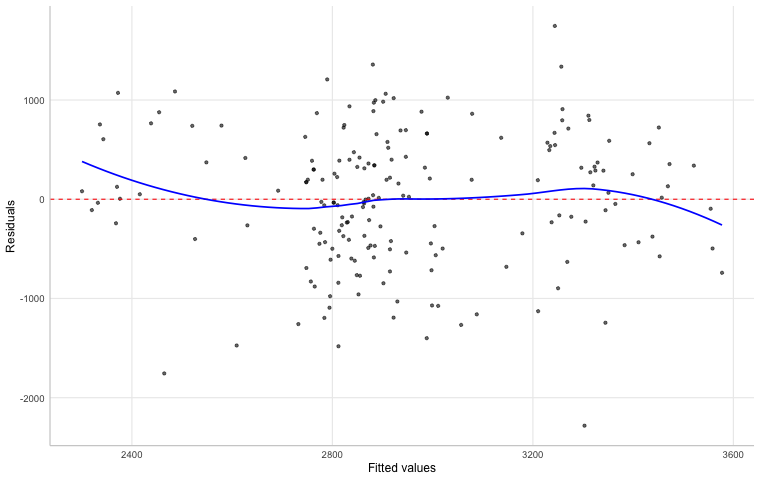

## 19. mc_impute_knn

用途：用 K 近邻法填补数值列的缺失值，适合缺失比例不高、且变量间存在相关性的场景。 方法：只对数值列处理。先按列标准化（减均值除标准差），再用欧氏距离为每个缺失点寻找最近的 k 个非缺失观测，取它们均值回填；标准差为 0 的列退化为用列均值填补。非数值列的缺失值原样保留并给出警告。 参数：.data 为数据框；k 为近邻个数，默认 5。 结果：返回与输入结构一致的填补后数据框。 注意：KNN 对量纲敏感，故内部已做标准化；但不同列取值范围差异极大时仍建议先用 mc_scale()。分类变量不参与 KNN，需另行处理（如众数填补或合并类别）。

**示例代码 / Example**

```
# 第 2 章：以 iris 演示 KNN 缺失值填补
data(iris)
set.seed(105)
iris_na &lt;- iris
iris_na$Sepal.Length[sample(150, 15)] &lt;- NA
iris_na$Sepal.Width[sample(150, 15)] &lt;- NA
head(mc_impute_knn(iris_na, k = 3))
```

**运行结果 / Output**

Sepal.Length Sepal.Width Petal.Length Petal.Width Species 1 5.1 3.5 1.4 0.2 setosa 2 4.8 3.0 1.4 0.2 setosa 3 4.7 3.2 1.3 0.2 setosa 4 4.6 3.1 1.5 0.2 setosa 5 5.0 3.6 1.4 0.2 setosa 6 4.8 3.9 1.7 0.4 setosa

## 20. mc_impute_mice

用途：用链式方程多重填补（MICE）处理缺失，适合缺失机制较复杂、希望保留不确定性的场景，并在事后给出每列缺失回填的量化诊断。 依赖：需要 mice 包（位于 Suggests），未安装时会报错提示。 方法：对每个缺失变量，以其它与它相关的变量为预测因子循环建模，迭代生成多个完整数据集，从而保留缺失带来的不确定性。 参数：.data 为数据框；m 为填补次数（生成 m 个完整数据集），默认 5；method 传 NULL 表示自动选择；... 透传给 mice::mice()。 结果：返回列表，含 mids（原始多重填补对象，可做进一步分析）、long（由 mice::complete(action="long") 得到的长表），以及 summary——**原创诊断表**：逐变量给出 n_missing_original（原始缺失数）、n_imputed（被回填的观测数）、pct_imputed（回填比例）。 注意：多重填补后的分析不应只看某一个数据集，而应使用 mids 对象配合支持 mice 的下游函数（如 with()/pool()）合并结果；summary 仅用于快速核查哪些变量被填补、填补了多少，不代表填补质量本身。

**示例代码 / Example**

```
# 第 2 章：链式方程多重填补（MICE），并给出逐变量回填诊断
set.seed(106)
n &lt;- 44
df &lt;- data.frame(
  age  = c(rnorm(n - 4, 50), NA, NA, rnorm(2, 55)),
  bili = c(NA, rnorm(n - 4, 1.2), NA, rnorm(2, 1.5)),
  chol = rnorm(n, 200, 40), stringsAsFactors = FALSE)
res &lt;- mc_impute_mice(df, m = 3)
head(res$long)
print(res$summary)   # 原创：逐变量缺失回填诊断
```

⚠ （标记为 \dontrun，本环境未自动运行；演示数据预处理流程）

## 21. mc_dedup

用途：去除重复行，常用于清洗重复录入或重复随访记录。 参数：.data 为数据框；by 指定用于判断重复的键列（如受试者 ID），NULL 表示按所有列判断；keep 选择保留每组的 "last"（默认）或 "first" 行。 结果：返回去重后的数据框。 注意：当指定 by 时，只比较这些键列是否相同，其余列即使不同也会被判为重复并只保留一行——因此请确保键列能唯一标识一条记录，否则可能误删信息。这与 Excel 的「删除重复项」语义一致。

**示例代码 / Example**

[output not shown]

**运行结果 / Output**

subj measure visit 1 1 a 1 3 2 b 3 5 3 c 5

## 22. mc_scale

用途：对数值列做特征缩放，常用于消除量纲差异、加速模型收敛，或为某些算法（如 KNN、正则化回归）准备数据。 方法：支持三种缩放——z（默认，z-score：减均值除标准差，结果均值 0、标准差 1）、minmax（线性归一到 [0,1]）、robust（减中位数除 IQR，对异常值稳健）。 参数：.data 为数据框；cols 指定要缩放的列，NULL 表示全部数值列；method 选择上述三种之一。 结果：返回仅数值列被替换、其余列不变的数据框。 注意：缩放会抹掉原始量纲，模型系数因此难以直接解释实际单位；若需解释性，建议保留原始变量或记录缩放参数以便还原。缺失值在缩放时按列剔除计算。

**示例代码 / Example**

[output not shown]

## 23. mc_wide_long

用途：把宽表（同一受试者的多次测量放在不同列）转换为长表（每次测量占一行），是数据处理的核心步骤。 方法（原创，原生实现）：先校验 id_cols 与 measure_vars 都存在于数据框；随后对每个测量列，将标识列按测量列数复制堆叠，并把测量列名作为「变量名」、对应取值作为「取值」逐列合并，输出整齐的长表。全程仅用 base R，无外部依赖。 参数：.data 为数据框；id_cols 为需保留的标识列（如 ID、分组）；measure_vars 为要拉长的测量列；name_to/value_to 分别为输出中「变量名」与「取值」列名，默认 variable / value。 结果：返回长格式数据框。 注意：转换后行数 = 原行数 × 测量列数；这是 mc_long_wide() 的逆操作。若测量列带有时间后缀（如 t1/t2/t3），转换后得到整齐的「时间-取值」两列，便于做重复测量分析。标识列为因子时会被保留为因子；测量列应类型一致，否则「取值」列会被强制转换为公共类型。

**示例代码 / Example**

```
# 第 2 章：纵向血压测量的宽表转为长表（t1/t2/t3 三次访视）
wide &lt;- data.frame(id = 1:4,
  t1 = rnorm(4, 120), t2 = rnorm(4, 122), t3 = rnorm(4, 118))
mc_wide_long(wide, id_cols = "id", measure_vars = c("t1", "t2", "t3"))
```

**运行结果 / Output**

id variable value 1 1 t1 119.9184 2 1 t2 122.1179 3 1 t3 118.7748 4 2 t1 120.4682 5 2 t2 123.0189 6 2 t3 117.5466 7 3 t1 119.4067 8 3 t2 122.8044 9 3 t3 117.1743 10 4 t1 119.9688 11 4 t2 121.8925 12 4 t3 116.9956

## 24. mc_long_wide

用途：把长表按名称列展开回宽表，是 mc_wide_long() 的逆操作，常用于把「时间-取值」长表还原为受试者×时间点的宽矩阵。 方法（原创，原生实现）：先取标识列的唯一组合作为输出行的骨架；再对名称列的每个取值，按「标识键 → 取值」的关系把对应 value_from 填回该新列。使用自定义的键拼接与匹配完成展开，全程仅依赖 base R。 参数：.data 为长表；id_cols 为标识列；name_from 提供新列名的来源列；value_from 提供填充值的来源列。 结果：返回宽格式数据框。 注意：若标识+名称存在重复组合（同一 ID 同一名称出现多次），展开时按首次出现取值并给出警告，转换前应确保标识+名称唯一。这是 mc_wide_long() 的逆操作。

**示例代码 / Example**

```
# 第 2 章：把「访视-血压」长表还原为受试者×访视的宽表
long_df &lt;- data.frame(id = 1:2, variable = c("t1", "t2"),
                      value = c(120, 118))
mc_long_wide(long_df, id_cols = "id",
  name_from = "variable", value_from = "value")
```

⚠ （标记为 \dontrun，本环境未自动运行；演示数据预处理流程）

## 25. mc_logistic

**示例代码 / Example**

```
# 第 5 章 5.7 节：低出生体重的多因素 logistic 回归
birthwt &lt;- MASS::birthwt
mc_logistic(birthwt, low ~ age + lwt + smoke + factor(race))
```

**运行结果 / Output**

# A tibble: 6 × 7 term estimate std.error statistic p.value conf.low conf.high &lt;chr&gt; &lt;dbl&gt; &lt;dbl&gt; &lt;dbl&gt; &lt;dbl&gt; &lt;dbl&gt; &lt;dbl&gt; 1 (Intercept) 1.39 1.11 0.300 0.764 0.164 12.9 2 age 0.978 0.0342 -0.658 0.511 0.913 1.04 3 lwt 0.988 0.00639 -1.96 0.0498 0.974 0.999 4 smoke 2.87 0.380 2.77 0.00552 1.38 6.19 5 factor(race)2 3.43 0.517 2.38 0.0172 1.25 9.63 6 factor(race)3 2.57 0.416 2.27 0.0234 1.15 5.94

## 26. mc_logistic_screen

用途：一键实现「先单因素筛选、再多因素建模」的经典流行病学套路，省去手动分步的麻烦。 方法：先对每个候选 x_vars 单独跑单因素 logistic 回归，按 alpha 阈值（默认 0.05）筛选显著变量，再把入选变量一起放进多因素模型。 参数：data 为数据框；y 为二分类结局列名（字符串）；x_vars 为候选自变量列名向量；alpha 为单因素筛选的显著性阈值；conf 为置信水平。 结果：返回列表，含 univariate（各变量单因素结果）、selected（入选变量名）、multivariable（多因素整洁系数表）。 注意：此方法方便但不是金标准——逐步/筛选可能引入选择偏倚与过拟合，且单因素显著≠多因素显著（变量间可能相互掩盖或放大）。报告时应同时呈现单因素与多因素结果，并说明筛选规则。最终模型仍建议用 mc_logistic() 复核。

**示例代码 / Example**

```
# 第 5 章（拓展阅读）：先单因素筛选、再多因素建模（"先单后多"）
birthwt &lt;- MASS::birthwt
bw &lt;- birthwt
bw$race  &lt;- factor(bw$race)
bw$smoke &lt;- factor(bw$smoke)
res &lt;- mc_logistic_screen(bw, y = "low",
                          x_vars = c("age","lwt","race","smoke","ht","ui"))
cat("==== 单因素 / univariate ====\n"); print(res$univariate, row.names = FALSE)
cat("\n==== 入选变量 / selected ====\n"); print(res$selected)
cat("\n==== 多因素 / multivariable ====\n"); print(as.data.frame(res$multivariable), row.names = FALSE)
```

**运行结果 / Output**

==== 单因素 / univariate ==== variable OR CI.low CI.high p.value age 0.9501333 0.8912949 1.0090269 0.10454800 lwt 0.9860401 0.9733982 0.9973535 0.02268856 race 1.8892340 0.9565420 3.7578709 0.06740445 smoke 2.0219436 1.0818724 3.8005817 0.02761962 ht 3.3653846 1.0283810 11.8291181 0.04606314 ui 2.5777778 1.1332019 5.8812628 0.02308380 ==== 入选变量 / selected ==== [1] "lwt" "smoke" "ht" "ui" ==== 多因素 / multivariable ==== term estimate std.error statistic p.value conf.low conf.high (Intercept) 2.0582484 0.849074041 0.8501677 0.395231859 0.4112178 11.7059787 lwt 0.9838264 0.006546259 -2.4908660 0.012743219 0.9704422 0.9958362 smoke1 1.9212914 0.335676465 1.9453183 0.051736682 0.9953210 3.7267842 ht 6.8354818 0.682665413 2.8156208 0.004868309 1.8590581 28.5951632 ui 2.4504346 0.442935919 2.0234652 0.043025209 1.0219543 5.8746967 variable (Intercept) lwt smoke1 ht ui

## 27. mc_stepwise

用途：基于信息准则（AIC）做逐步变量选择，自动从全模型中增删变量，得到更简洁的回归模型。 方法：以 AIC 最小化为目标，支持 both（默认，双向，可进可出）、backward（从全模型删）、forward（从空模型加）；k 为惩罚项（默认 2 对应 AIC，取 log(n) 可得 BIC）。 参数：data 为数据框；formula 为含全部候选自变量的公式；direction 选择方向；k 为 AIC/BIC 惩罚。 结果：返回列表，含最终 coefficients（系数表）与 formula（最终入选变量的公式）。 注意：逐步回归便于探索，但统计上存在缺陷——p 值被低估、置信区间偏窄、易过拟合，且结果依赖进入/剔除的随意阈值。它适合做变量筛选的「初稿」，重要结论仍需用领域知识与预先注册的分析计划支撑。

**示例代码 / Example**

```
# 第 5/7 章：基于 AIC 的逐步变量选择
birthwt &lt;- MASS::birthwt
bw &lt;- birthwt
bw$race  &lt;- factor(bw$race)
bw$smoke &lt;- factor(bw$smoke)
mc_stepwise(bw, low ~ age + lwt + race + smoke + ht + ui)$coefficients
```

**运行结果 / Output**

# A tibble: 7 × 8 term estimate std.error statistic p.value conf.low conf.high variable &lt;chr&gt; &lt;dbl&gt; &lt;dbl&gt; &lt;dbl&gt; &lt;dbl&gt; &lt;dbl&gt; &lt;dbl&gt; &lt;chr&gt; 1 (Intercept) 1.06 0.938 0.0600 0.952 0.177 7.10 (Intercep… 2 lwt 0.983 0.00680 -2.46 0.0139 0.970 0.996 lwt 3 race2 3.76 0.521 2.54 0.0111 1.36 10.7 race2 4 race3 2.52 0.430 2.15 0.0314 1.10 6.01 race3 5 smoke1 2.82 0.393 2.64 0.00832 1.32 6.23 smoke1 6 ht 6.50 0.691 2.71 0.00676 1.74 27.5 ht 7 ui 2.47 0.448 2.02 0.0432 1.02 5.98 ui

## 28. mc_ordinal_logistic

用途：拟合有序 logistic 回归（比例优势模型），适用于结局为有序多分类（如轻/中/重度）的场景。 方法：基于 MASS 包的 polr()，假设各分割点的自变量效应相同（比例优势假设）。 参数：data 为数据框；formula 形如 有序结局 ~ 自变量，结局必须是有序因子（ordered()）。 结果：返回含系数（logit 尺度）、标准误、与已指数化的 OR（优势比）的系数表。 注意：若比例优势假设不成立（可用 MASS::polr 配合检验或分层的 OR 差异大），结果解释需谨慎，可改用部分比例优势模型或无序多分类 logistic。务必先把结局转成 ordered 因子，否则模型无意义。依赖 MASS（Suggests）。

**示例代码 / Example**

```
# 第 5 章：有序 logistic——产前检查次数(ftv)的 ordinal 结局
birthwt &lt;- MASS::birthwt
bw &lt;- birthwt
bw$ftv_ord &lt;- ordered(cut(bw$ftv, c(-1, 0, 2, Inf),
                         labels = c("0次", "1-2次", "3次+")))
bw$smoke &lt;- factor(bw$smoke)
mc_ordinal_logistic(bw, ftv_ord ~ age + lwt + smoke)
```

**运行结果 / Output**

Value Std. Error t value variable OR age 0.092966654 0.028331971 3.2813337 age 1.0974251 lwt 0.001121557 0.004970938 0.2256229 lwt 1.0011222 smoke1 -0.400497344 0.303991094 -1.3174641 smoke1 0.6699867 0次|1-2次 2.281372711 0.873638060 2.6113477 0次|1-2次 9.7901102 1-2次|3次+ 4.989439717 0.951283120 5.2449577 1-2次|3次+ 146.8541205 p.value age 1.033174e-03 lwt 8.214948e-01 smoke1 1.876831e-01 0次|1-2次 9.018616e-03 1-2次|3次+ 1.563182e-07

## 29. mc_clogistic

用途：分析配对（匹配）病例对照数据中暴露与结局的关联，控制配对变量带来的混杂。 依赖：需要 survival 包（位于 Suggests）；未安装时给出明确提示。 方法：在公式内用 \code{strata(配对变量)} 指定配对层，\code{survival::clogit()} 在每层内做条件 logistic 似然估计。 参数：\code{data} 为数据框；\code{formula} 为模型公式，响应变量为 0/1（1=病例）， 必须含 \code{strata(配对变量)} 项。 结果：返回系数表，含估计值、标准误、z 值、p 值、OR（exp(估计)）与 OR 的 95% 置信区间。OR&gt;1 表示该暴露为危险因素。 注意：每个配对层内应同时包含病例与对照；若某层只有一种状态，该层对条件 似然无贡献。模型比较可配合 mc_model_compare() 使用。

**示例代码 / Example**

[output not shown]

## 30. mc_model_compare

用途：在多个候选回归模型间做信息准则比较，选出相对最优者。 方法（自研）：AIC、BIC 取自基础 R；AICc = AIC + 2k(k+1)/(n-k-1)（k 为参数数、 n 为样本量，对样本量小于参数数+1 的模型记为 NA）；再计算 delta = AICc - min， Akaike 权重 w = exp(-0.5*delta) / sum(exp(-0.5*delta))，权重越大模型越优。 参数：\code{...} 为若干已拟合模型对象（如 lm/glm/coxph 等，需支持 \code{AIC()}/\code{BIC()}/\code{nobs()}）；\code{n} 为样本量（缺省时尝试用 \code{nobs()} 自动获取）。 结果：返回按权重降序排列的模型比较表，含 k（参数数）、n、AIC、BIC、AICc、 delta_AICc、weight。 注意：比较的模型必须基于同一数据集与同一响应变量，否则准则不可比。权重反映 各模型相对最优的概率，不表示绝对拟合优度。

**示例代码 / Example**

```
# 第 5 章 5.8 节：比较预测出生体重的多个线性模型（AIC/BIC/AICc/权重）
birthwt &lt;- MASS::birthwt
m1 &lt;- lm(bwt ~ lwt, data = birthwt)
m2 &lt;- lm(bwt ~ lwt + age, data = birthwt)
m3 &lt;- lm(bwt ~ lwt + age + smoke + factor(race), data = birthwt)
mc_model_compare(m1, m2, m3)
```

**运行结果 / Output**

model k n AIC BIC AICc delta_AICc weight 3 model3 6 189 3010.782 3033.474 3011.243 0.00000 0.9992913826 1 model1 2 189 3026.485 3036.210 3026.549 15.30613 0.0004742513 2 model2 3 189 3027.829 3040.796 3027.959 16.71583 0.0002343661

## 31. mc_survfit

**示例代码 / Example**

[output not shown]

**运行结果 / Output**

---- log-rank 检验 / test ---- test chisq p.value log-rank 1.544661 0.2139253

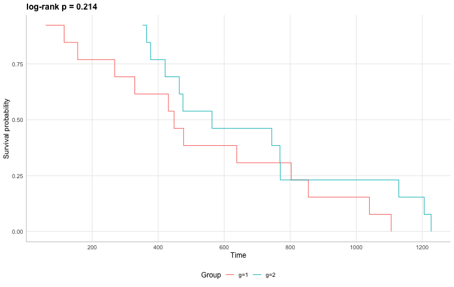

## 32. mc_cox

用途：拟合 Cox 比例风险模型，评估多个协变量对发生事件风险的同期影响，得到风险比（HR）。 方法：半参数模型，不假设基线风险形态，只估计协变量对应的风险比；默认对比例风险（PH）假设做检验。 参数：data 为数据框；formula 形如 Surv(time, status) ~ 协变量，需用 survival::Surv() 构造生存对象；conf 为 HR 置信水平。 结果：返回列表，含 coefficients（各变量 HR、标准误、z、p 值与置信区间）、ph_test（比例风险假设检验结果）、以及 forest（HR 森林图，ggplot 对象）。 注意：HR&gt;1 表示该协变量升高时事件风险升高。PH 假设是 Cox 的核心前提——若 ph_test 提示显著违背（如某变量 p 很小），需考虑分层 Cox、时变效应或改参数模型。森林图用 print(res$forest) 查看。

**示例代码 / Example**

```
# 第 6 章：Cox 比例风险模型——卵巢癌生存预后
ovarian &lt;- survival::ovarian
ov &lt;- ovarian
ov$status &lt;- ifelse(ov$fustat == 2, 0, 1)
res &lt;- mc_cox(ov, survival::Surv(futime, status) ~ age + rx + resid.ds + ecog.ps)
cat("---- HR 表 / coefficients ----\n"); print(as.data.frame(res$coefficients), row.names = FALSE)
cat("\n---- PH 假设检验 / PH test ----\n"); print(res$ph_test)
print(res$forest)
```

**运行结果 / Output**

---- HR 表 / coefficients ---- term estimate std.error statistic p.value conf.low conf.high age 1.0962776 0.02700533 3.4037894 0.0006645798 1.0397611 1.1558661 rx 0.3331206 0.45324386 -2.4252964 0.0152958926 0.1370249 0.8098477 resid.ds 2.0817876 0.46597273 1.5735404 0.1155937339 0.8352177 5.1888739 ecog.ps 0.8057015 0.42622620 -0.5068715 0.6122449925 0.3494377 1.8577129 variable age rx resid.ds ecog.ps ---- PH 假设检验 / PH test ---- chisq df p age 3.09914985 1 0.07833319 rx 1.18971667 1 0.27538671 resid.ds 0.05569684 1 0.81343130 ecog.ps 0.04926883 1 0.82434049 GLOBAL 3.64084235 4 0.45678843

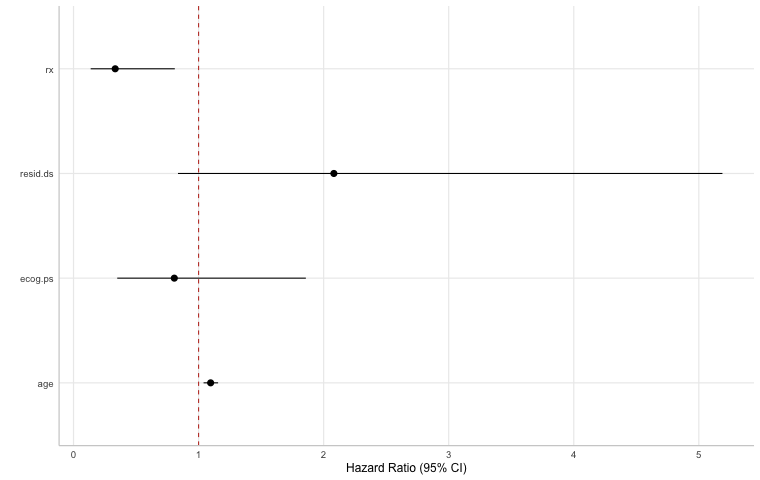

## 33. mc_competing_risk

用途：在存在「竞争事件」时做回归，避免把竞争事件误当作删失而高估目标事件风险。典型场景：研究死亡为竞争事件的复发分析。 方法：基于 cmprsk 包的 Fine-Gray 子分布风险模型（subdistribution hazard），将竞争事件作为特殊的删失处理，直接估计目标原因累积发生率。 参数：data 为数据框；time 为时间列；status 为状态列（0=删失，&gt;0 代表不同事件类型）；group 为分组/暴露变量；cause 指定关注的目标事件编号（默认 1）。 结果：返回列表，含 coefficients（各变量对应的子分布风险比 SHR、标准误、z、p 值）。 注意：status 的编码约定与 mc_survfit()/mc_cox() 不同：这里 0 才是删失，其它正整数各代表一类事件，务必按此约定整理数据。若仅有一个事件类型且无竞争，普通 Cox 即可。依赖 cmprsk（Suggests）。

**示例代码 / Example**

```
# 第 8 章 8.2 节：白血病复发(1)与死亡(2)的竞争风险
# 关注事件 cause = 1（复发）；死亡为竞争事件，不能当作删失
set.seed(126)
n &lt;- 300
trt     &lt;- sample(c(0,1), n, TRUE)
ftime   &lt;- rexp(n, .05)
fstatus &lt;- sample(0:2, n, TRUE, c(.4,.35,.25))   # 0删失 1复发 2死亡(竞争)
df &lt;- data.frame(ftime = ftime, fstatus = fstatus, trt = trt)
res &lt;- mc_competing_risk(df, time = "ftime", status = "fstatus", group = "trt", cause = 1)
print(res$coefficients)
```

⚠ 依赖可选包（`mc_competing_risk` cmprsk）本环境未安装，示例仅展示代码

## 34. mc_multistate

用途：拟合多状态生存模型，研究个体在多个健康状态间（如健康→并发症→死亡）的转移风险，比单一终点更贴近临床过程。 方法：基于 mstate 包，先把随访数据展开为「起点-终点」的转移长表，再用 coxph() 对每条转移分别建模。 参数：data 为已展开的多状态长表（含 id、Tstart、Tstop、status、from、to 等列）；trans 为转移矩阵（由 mstate::transMat() 构造，定义状态间允许哪些转移）；formula 含生存对象与协变量，可用 strata(trans) 对转移类型分层。 结果：返回列表，含 model（各转移的 coxph 拟合）、msfit（用于预测累积转移概率的 msfit 对象）。 注意：输入数据必须已是 mstate 要求的长表格式（非原始宽表），trans 的编号必须与 from/to 列及 strata(trans) 一致；构造错误会导致「所有观测同组」或无转移可估。依赖 mstate（Suggests）。

**示例代码 / Example**

```
# 第 8 章：三状态模型（健康 H -&gt; 并发症 I / 直接死亡 D）
set.seed(127)
library(mstate)
n &lt;- 150
age &lt;- rnorm(n, 55, 8)
t12 &lt;- rexp(n, .15); t23 &lt;- rexp(n, .20); t13 &lt;- rexp(n, .10)
rows &lt;- list()
for (i in 1:n) {
  if (runif(1) &lt; .6) {
    rows[[length(rows)+1]] &lt;- data.frame(id=i, Tstart=0,      Tstop=t12[i],        status=1, from=1, to=2, age=age[i])
    rows[[length(rows)+1]] &lt;- data.frame(id=i, Tstart=t12[i], Tstop=t12[i]+t23[i], status=1, from=2, to=3, age=age[i])
  } else {
    rows[[length(rows)+1]] &lt;- data.frame(id=i, Tstart=0, Tstop=t13[i], status=1, from=1, to=3, age=age[i])
  }
}
ms &lt;- do.call(rbind, rows)
trans &lt;- transMat(list(c(2,3), c(3), c()), names = c("H","I","D"))
ms$trans &lt;- with(ms, ifelse(from == 1 & to == 2, 1, ifelse(from == 1 & to == 3, 2, 3)))
fit &lt;- mc_multistate(ms, trans = trans, formula = survival::Surv(Tstart, Tstop, status) ~ age + strata(trans))
cat("coxph 系数 / coxph coefficients:\n")
print(summary(fit$model)$coefficients)
cat("\nmsfit 类别 / class:", class(fit$msfit)[1], "\n")
```

⚠ （依赖 cmprsk / mstate 等可选包，本环境未安装，示例仅展示代码）

## 35. mc_ph_test

用途：检验 Cox 比例风险模型的核心假设——各协变量的风险比是否随时间恒定。 依赖：需要 survival 包（已在 Imports 中）。 方法：Schoenfeld 残差应随时间无趋势；\code{survival::cox.zph()} 对每条曲线做 平滑后做相关检验，p&gt;0.05 通常认为满足 PH 假定。 参数：\code{fit} 为已拟合的 \code{coxph} 对象（可由 mc_cox() 返回）；或传入 \code{data} 与 \code{formula} 由函数先拟合。 结果：返回列表——\code{test}（检验表：变量/卡方/df/p 值，含 Global 行）、 \code{plot}（标准化 Schoenfeld 残差 vs 时间的 ggplot，可指定 \code{which} 变量，默认第一个协变量）。 注意：样本量较小或事件数较少时 PH 检验功效低；若违反 PH 假定，可考虑分层 Cox、加入时间依存项或改用 mc_competing_risk() 等替代模型。

**示例代码 / Example**

```
# 第 6 章 6.5 节：检验卵巢癌 Cox 模型的比例风险假定
ovarian &lt;- survival::ovarian
ov &lt;- ovarian
ov$status &lt;- ifelse(ov$fustat == 2, 0, 1)
fit &lt;- survival::coxph(survival::Surv(futime, status) ~ age + rx + resid.ds, data = ov)
r &lt;- mc_ph_test(fit)
print(r$test)        # 各协变量 PH 检验表
print(r$plot)        # 标准化 Schoenfeld 残差 vs 时间
```

**运行结果 / Output**

variable chisq df p_value age age 3.1621102 1 0.07536571 rx rx 1.0925327 1 0.29591074 resid.ds resid.ds 0.0367104 1 0.84805588 GLOBAL GLOBAL 3.4683032 3 0.32489642

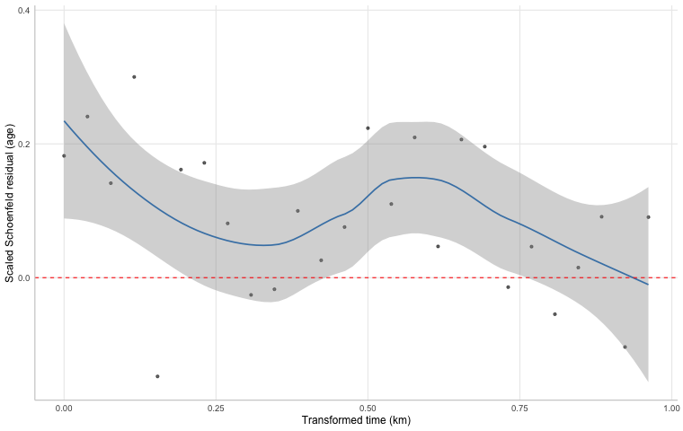

## 36. mc_mode

用途：找出数据中出现频率最高的取值（众数）。R 基础语言没有内置众数函数，这里是面向教学的自实现版本。 参数：x 接受数值或因子向量；na.rm 决定是否在计数前剔除缺失值（默认 TRUE，缺失值不计入频率）。 结果：返回全部并列最高频的取值，因此天然支持「多众数」——双峰分布会同时返回两个众数；返回类型与输入保持一致（数值输入返回数值型向量）。 注意：若每个取值都只出现一次，则所有值都会被判为「众数」并原样返回，这种情况通常没有实际意义；使用前可先用 mc_inspect() 了解分布形态。当所有观测都是缺失值时返回 NULL。

**示例代码 / Example**

[output not shown]

## 37. mc_inspect

用途：建模前快速把脉数据质量，逐列给出类型、观测数、缺失数、缺失百分比与唯一值个数。 参数：.data 为数据框或 tibble，无需其它参数。 结果：返回一个数据框，每行对应输入的一列，列为 variable（列名）、class（类别）、n（有效观测数）、n_missing（缺失数）、pct_missing（缺失百分比）、n_unique（唯一值个数）。 注意：n 是剔除缺失后的有效观测数，因此 n + n_missing 等于该列总长度，缺失百分比按列总长度计算。这是预处理流水线第一道「体检」步骤，建议在任何清洗/建模之前先跑一遍。

**示例代码 / Example**

```
# 第 1 章：用 birthwt 体检数据框把脉数据质量（可先人为制造缺失演练）
birthwt &lt;- MASS::birthwt
mc_inspect(birthwt[, c("age", "lwt", "bwt", "smoke", "low")])
```

**运行结果 / Output**

variable class n n_missing pct_missing n_unique 1 age integer 189 0 0 24 2 lwt integer 189 0 0 75 3 bwt integer 189 0 0 131 4 smoke integer 189 0 0 2 5 low integer 189 0 0 2

## 38. mc_theme

用途：提供一套浅色、克制、留白充足的 ggplot2 主题，用于报告出图，与多个分析函数返回值中的 plot 组件（如 mc_survfit()、mc_cox()、mc_rcs()）配色一致。 参数：base_size 控制基础字号，默认 12。 结果：返回一个 ggplot2 主题对象，可用 + 追加到任意 ggplot 图形之后。 注意：这是纯主题（theme），不含几何对象（geom），必须配合 geom_point()、geom_line() 等图层使用；想换配色请配合 mc_palette() 一起使用。

**示例代码 / Example**

```
library(ggplot2)
# 第 3 章：母亲孕期体重与出生体重的散点（按是否吸烟着色）
birthwt &lt;- MASS::birthwt
p &lt;- ggplot(birthwt, aes(lwt, bwt, color = factor(smoke))) +
  geom_point(size = 2, alpha = 0.6) + mc_theme(base_size = 13)
print(p)
```

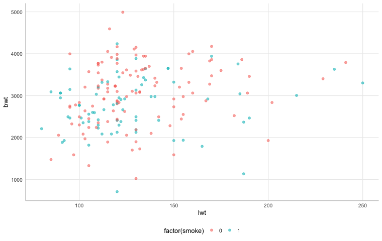

## 39. mc_palette

用途：返回品牌基准色并保证出图配色一致；当类别数超过 6 个时，可在基准色之间插值生成所需数量的颜色，避免手动配色。 方法（原创）：内部先自行把 "#RRGGBB" 解析为 0–255 的 RGB 三元组（.hex_to_rgb），在锚点颜色间按位置做线性插值（.interp_palette），再把结果还原为十六进制（.rgb_to_hex）；整个过程不调用任何调色板包。 参数：n 为需要生成的颜色个数，NULL（默认）时返回六个固定品牌色；type 选择 "brand"（默认，六个离散品牌色）、"gradient"（品牌色间的连续渐变，默认 100 色）、"discrete"（在品牌色基础上插值出的离散色板）。 结果：默认返回一个带名字的字符向量，含 primary（主蓝）、secondary（紫）、accent（绿）、warn（红）、info（青）、muted（灰）六个品牌色；指定 n 时返回长度 n 的颜色向量（gradient 默认无名，discrete/brand 保留锚点名）。 注意：这是纯算法生成的配色，不依赖任何数据；插值为线性 RGB 空间，如需感知更均匀的色板可后续改用 HCL 空间。常与 mc_theme() 搭配得到风格统一的报告图。

**示例代码 / Example**

```
pal &lt;- mc_palette()                 # 默认：六个品牌色
print(pal)
grad &lt;- mc_palette(n = 20, type = "gradient")  # 20 色连续渐变
print(head(grad))
library(ggplot2)
df &lt;- data.frame(name = factor(names(pal), names(pal)), col = pal)
p &lt;- ggplot(df, aes(name, fill = name)) + geom_bar() +
  scale_fill_manual(values = pal) + theme_void()
print(p)
```

**运行结果 / Output**

primary secondary accent warn info muted "#1A439C" "#511B78" "#1C7331" "#C0392B" "#0E7C86" "#8A94A6" [1] "#0E7C86" "#0F7688" "#11708B" "#126A8D" "#13648F" "#145E92"

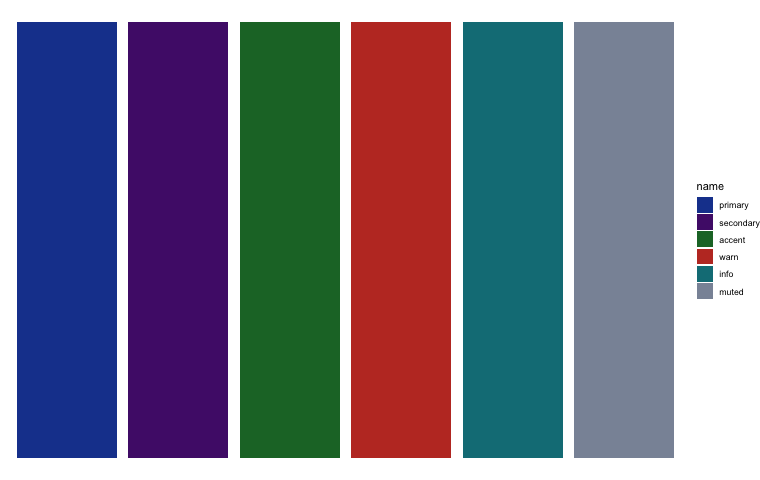